# CSDA1050 Capstone Project Sprint2

## Linear Regression2:

### Now plotting # of hires and revenue together.

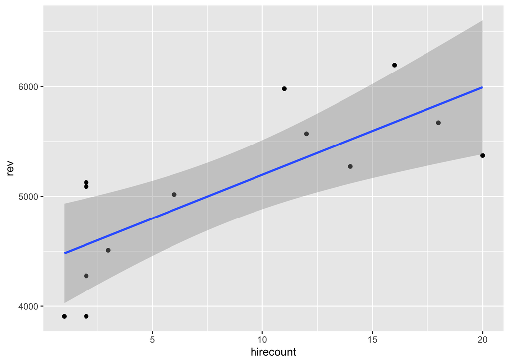

```r
ggplot(hire, aes(x=hirecount, y=rev)) + geom_point() +geom_smooth(method='lm')+ scale_x_continuous(labels = scales::comma)
```

### A linear model between # of hires & revenue. A correlation can be observed again.

```r
lm2 <- lm(hirecount ~ rev, data = hire)
summary(lm2)
```

```
##
## Call:
## lm(formula = hirecount ~ rev, data = hire)
##
## Residuals:
##     Min      1Q  Median      3Q     Max
## -6.8042 -2.0095 -0.5267  2.0019  9.4332
##
## Coefficients:
##               Estimate Std. Error t value Pr(>|t|)
## (Intercept) -28.233459   9.580587  -2.947  0.01328 *
## rev           0.007224   0.001872   3.859  0.00266 **
## ---
## Signif. codes:  0 '***' 0.001 '**' 0.01 '*' 0.05 '.' 0.1 ' ' 1
##
## Residual standard error: 4.77 on 11 degrees of freedom
## Multiple R-squared:  0.5752, Adjusted R-squared:  0.5365
## F-statistic: 14.89 on 1 and 11 DF,  p-value: 0.002658
```

### When the same 500K year-over-year revenue growth is applied, the model suggests below # of new hires prediction.

```r
predict(lm2, newdata = data.frame((rev = c(5500, 6000, 6500, 7000))))
```

```
##        1        2        3        4
## 11.49873 15.11075 18.72276 22.33478
```

### Overall, this linear model analysis suggests that predicted hiring cost can be considered as opportunity cost to retain existing staff. The amounts are not insignificant. I feel that they are meaningful enough to actually propose solid career advancement & growth opportunity to individuals at risk, in a form of education and/or training.

```r
predict(lm1, newdata = data.frame((rev = c(5500, 6000, 6500, 7000))))
```

```
##        1        2        3        4
## 183.2955 241.6326 299.9696 358.3067
```

```r
predict(lm2, newdata = data.frame((rev = c(5500, 6000, 6500, 7000))))
```

```
##        1        2        3        4
## 11.49873 15.11075 18.72276 22.33478
```

## Conclusion

### Sprint2 analysis has started off with classification models such as Decision Tree and Random Forest. Although I was successful in increasing accuracy slightly, the overall performance was not satisfactory. Perhaps the failure was foreseen, given the limitation from small dataset. This does not mean that this analysis did not share any insights. As it was shown Data Exploration phase, this modelling has illustrated that more junior staff chooses to quit and more senior staff are terminated from the organization. Also bigger percentage in termination of senior staff hints that the organization tends to scrutinize senior staff’s performance. Another discovery is that there is correlation between revenue and hiring cost. While it seemed obvious that hiring cost increase as revenue increases, it is very meaningful to quantify hiring cost in different business situations so it can help build budget for employee retention purpose.

## Next step

### Discoveries from sprint 1 and 2 will be put into a report for stakeholders. The goal is to create a report that insightful and beneficial to related party who are not necessarily familiar with machine learning.